# Trial Roll on Analysis

Gabbi Caimmi

17 October, 2023

## The initiative

### Offering Standard Annual/Monthly and Premium Annual renewals for to prospect trialists

In a previous test from 2015, we tried offering Standard Trial in place of Premium Trials. Standard trials gained a 12% increase in volume. The 12% increase wasn’t enough to make up for the lower revenue gained from Standard Trials.  
We have a known subscriber dilemma where users who are not ready to sign up to a full-priced subscription must sacrifice a £1 month to sign up directly. If they choose a trial to gain the £1 month, they later have to manually cancel or change to the subscription type that they want if it isn’t Premium monthly, an expensive option that is less popular.

### Hypothesis

“ If we allow users to pick their own roll on term and subscription type then this will lead to an increase in volume for trials and retention of those trials. If we leave Premium Digital monthly as the default then we will keep our revenue intact. If we allow annual trials then we will increase revenue generated from trials in some cases.”

## Analysis

The experiment lasted for 30 days, during which it accrued about 50k visitors, among anonymous and registered, initiating the trial buy flow. We count around 3k b2c conversions per test group, resulting in a 13% conversion rate for control and 12.8% conversion rate for variant. The relative difference between variant and control conversion rate is 1.5%.

```r
start_date <- as.Date("2023-08-04")
end_date <- as.Date("2023-09-04")

  #can also use as.Date(.data$`_PARTITIONTIME`) in the filter clause for the optimizely table to filter the partitioning

joined_df <- pageview %>%
  filter(time_stamp_utc <= end_date,
         time_stamp_utc >= start_date) %>%
  inner_join(optimizely %>%
               partitiontime_between(start_date, end_date) %>%
               filter(optimizely_campaign_name == 'MVT-400: Trial Roll on Test')
               , by = "event_root_id",suffix = c("_pvs", "_opt")) %>%
  left_join(conversions %>% filter(is_b2c == TRUE), by = "visitor_id", suffix = c("_pvs", "_cv")) %>%
  filter( is.na(order_dtm) | order_dtm >= time_stamp_utc) %>%
  mutate(visitor_id = as.character(visitor_id),
         visit_id = as.character(visit_id),
         cancelled_same_day= as.character(cancelled_same_day),
         conversion_visit_id = as.character(conversion_visit_id)) %>%
  collect()


  df_filtered <- joined_df %>% select(event_id_pvs, event_root_id, time_day, time_stamp_utc, visit_id,
         visitor_id, user_guid_pvs, user_cohort, url_pvs, traffic_source_type_pvs, rollup_traffic_source_type,
         device_type_pvs, optimizely_campaign_name, optimizely_variations_name,
         user_guid_cv,subscriptionid,product_type, order_dtm, conversion_visit_id, subscription_start_dtm,cancelled_same_day,
         is_trial, is_b2c, main_product_name, arrangementproduct_name, arrangement_id, arrangementtype_name, number_of_periods,offer_id, user_guid_cv) %>%
    group_by(visitor_id) %>%
    mutate(count = n_distinct(optimizely_variations_name)) %>% ungroup() %>% arrange(desc(count)) %>% filter(count == 1)

# running checks on manipulation
df_filtered %>%
  group_by(optimizely_variations_name) %>%
  summarise(count_visitors = n_distinct(visitor_id),
            count_events = n_distinct(event_root_id),
            count_conversions = n_distinct(user_guid_cv),
            conversion_rate = round((count_conversions/count_visitors)*100, 1)) %>%
  arrange()
```

| optimizely_variations_name | count_visitors | count_events | count_conversions | conversion_rate |
| --- | --- | --- | --- | --- |
| Original | 23397 | 44894 | 3048 | 13.0 |
| Variation_1 | 23742 | 45040 | 3050 | 12.8 |

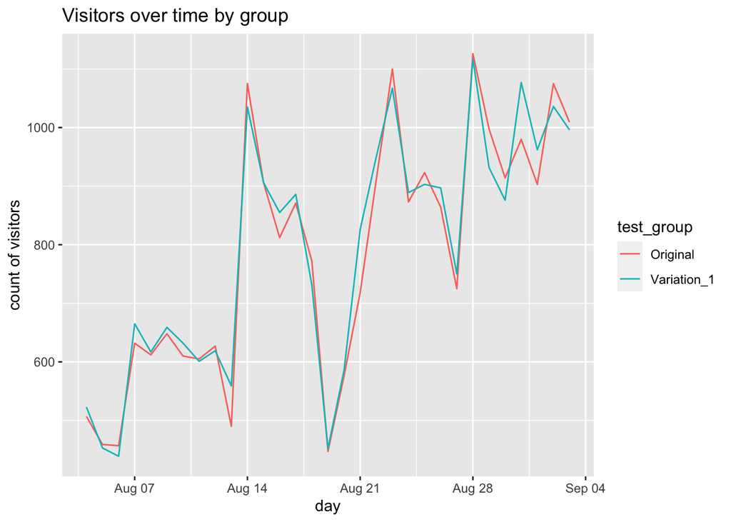

```r
df_filtered %>%
  group_by(optimizely_variations_name, time_day) %>%
  summarise(count = n_distinct(visitor_id)) %>%
  ungroup() %>%
  arrange(optimizely_variations_name, time_day) %>%
  ggplot(aes(time_day, count, color = optimizely_variations_name)) +
  geom_line() +
  labs(title = "Visitors over time by group",
       x = "day",
       y = "count of visitors",
       color = "test_group")
```

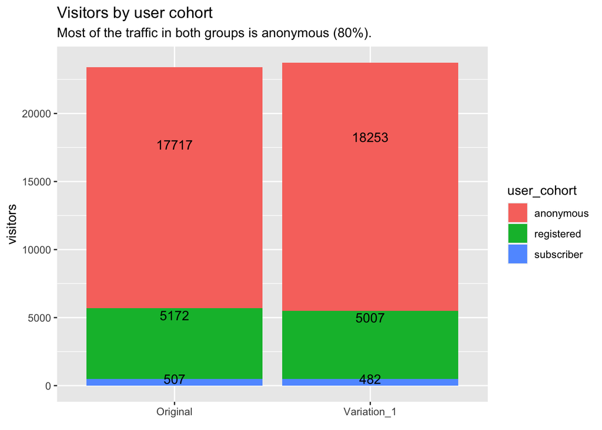

```r
df_filtered %>%
  group_by(optimizely_variations_name, visitor_id) %>% slice(which.min(time_day)) %>%
  ungroup() %>%
  group_by(optimizely_variations_name, user_cohort) %>%
  summarise(visitors = n_distinct(visitor_id)) %>%
  ungroup() %>%
  filter(user_cohort != 'weekend') %>%
  ggplot(aes(optimizely_variations_name, visitors, fill = user_cohort)) +
  geom_col() +
  labs(x = element_blank(),
       title = "Visitors by user cohort",
       subtitle = "Most of the traffic in both groups is anonymous (80%).") +
  geom_text(aes(label = visitors))
```

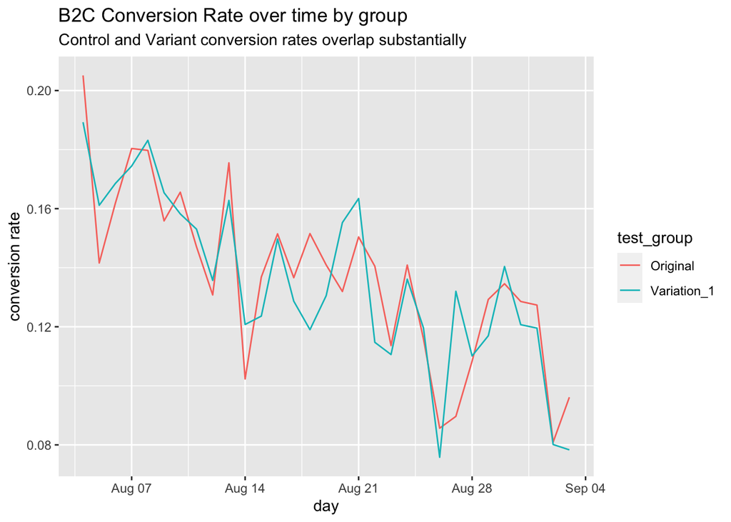

```r
df_filtered %>%
  group_by(optimizely_variations_name, time_day) %>%
  summarise(visitors = n_distinct(visitor_id),
            conversions = n_distinct(user_guid_cv)) %>%
  mutate(conversion_rate = conversions/visitors) %>%
  ungroup() %>%
  ggplot(aes(time_day, conversion_rate, color = optimizely_variations_name)) +
  geom_line()  +
  labs(title = "B2C Conversion Rate over time by group",
       subtitle = "Control and Variant conversion rates overlap substantially",
       x = "day",
       y = "conversion rate",
       color = "test_group")
```

```r
#total trial conversions split by term
trial_product_list <- df_filtered %>%
  distinct(optimizely_variations_name, visitor_id, arrangementtype_name, product_type, arrangementproduct_name, user_guid_cv, offer_id) %>%
  mutate(conversion_type = ifelse(product_type == "Digital" & arrangementtype_name == "B2C Trial"
                           & (arrangementproduct_name == "Premium FT.com" | arrangementproduct_name == "Standard FT.com"), "Digital Trial",
                           ifelse(!is.na(user_guid_cv), "Other Conversion", "No Conversion")
                           ),
         trial_name = ifelse(offer_id == "41218b9e-c8ae-c934-43ad-71b13fcb4465", "Premium Monthly"
                             , ifelse(offer_id == "03e5369b-783f-2f22-94d0-567e9dd95b56", "Standard Monthly"
                                      ,ifelse(offer_id == "0916a7ac-c7d9-6444-4278-0b98272d30a9", "Premium Annual", "Standard Annual")))
         ) %>%
  filter(conversion_type == "Digital Trial", offer_id != "Unknown")

trial_product <- trial_product_list %>% group_by(optimizely_variations_name, trial_name) %>%
  summarise(conversions = n_distinct(user_guid_cv)
            ) %>%
  ungroup() %>%
  filter(optimizely_variations_name == "Variation_1") %>%
  mutate(perc_total = round(conversions/(sum(conversions))*100,2)) %>%
  select(optimizely_variations_name, trial_name, conversions, perc_total) %>% arrange(desc(conversions))

trial_product
```

| optimizely_variations_name | trial_name | conversions | perc_total |
| --- | --- | --- | --- |
| Variation_1 | Premium Monthly | 2793 | 97.49 |
| Variation_1 | Standard Monthly | 62 | 2.16 |
| Variation_1 | Standard Annual | 8 | 0.28 |
| Variation_1 | Premium Annual | 2 | 0.07 |

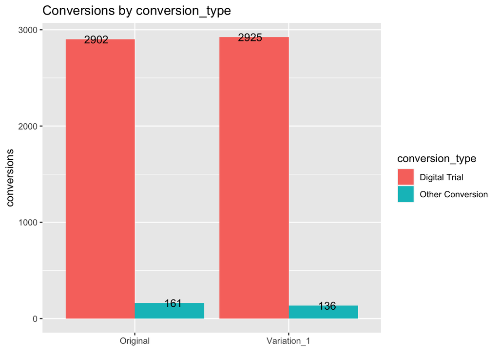

```r
#total conversions split by product
df_filtered %>%
  distinct(optimizely_variations_name, visitor_id, arrangementtype_name, product_type, arrangementproduct_name, user_guid_cv, offer_id) %>%
  mutate(conversion_type = ifelse(product_type == "Digital" & arrangementtype_name == "B2C Trial"
                           & (arrangementproduct_name == "Premium FT.com" | arrangementproduct_name == "Standard FT.com"), "Digital Trial",
                           ifelse(!is.na(user_guid_cv), "Other Conversion", "No Conversion")
                           )) %>%
  group_by(optimizely_variations_name, conversion_type) %>%
  summarise(conversions = n_distinct(user_guid_cv)) %>%
  filter(!is.na(conversion_type)) %>%
  ggplot(aes(optimizely_variations_name, conversions, fill = conversion_type)) +
  geom_col(position = "dodge") +
  labs(title = "Conversions by conversion_type",
       x = element_blank()) +
  geom_text(aes(label = conversions), position=position_dodge(width=1))
```

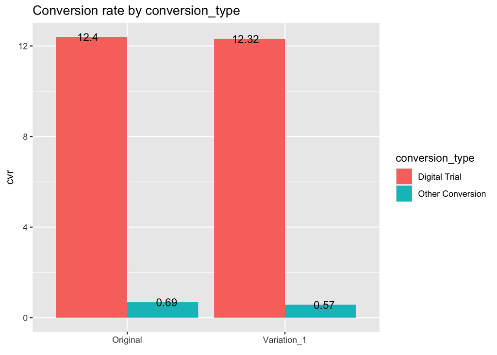

```r
#conversion rate split by product
df_filtered %>%
  distinct(optimizely_variations_name, visitor_id, arrangementtype_name, product_type, arrangementproduct_name, user_guid_cv) %>%
  mutate(conversion_type = ifelse(product_type == "Digital" & arrangementtype_name == "B2C Trial"
                           & (arrangementproduct_name == "Premium FT.com" | arrangementproduct_name == "Standard FT.com"), "Digital Trial",
                           ifelse(!is.na(user_guid_cv), "Other Conversion", "No Conversion")
                           )) %>%
  group_by(optimizely_variations_name) %>%
  mutate(visitors = n_distinct(visitor_id)) %>% ungroup() %>%
  group_by(optimizely_variations_name, conversion_type) %>%
  mutate(conversions_by_type = n_distinct(user_guid_cv)) %>% ungroup() %>%
  distinct(optimizely_variations_name, conversion_type, visitors, conversions_by_type) %>%
  filter(!is.na(conversion_type)) %>%
  arrange(optimizely_variations_name,conversion_type) %>%
  mutate(cvr = round(conversions_by_type/visitors,4)*100) %>%
  ggplot(aes(optimizely_variations_name, cvr, fill = conversion_type)) +
  geom_col(position = 'dodge') +
  labs(title = "Conversion rate by conversion_type",
       x = element_blank()) +
  geom_text(aes(label = cvr), position=position_dodge(width=1))
```

Indeed when calculating p-values for overall b2c conversion rate and trial-only conversion rate, we can’t conclude any significant shift among conversion metrics.

```r
#significance analysis for conversion rates
df_filtered_significance <- df_filtered %>%
distinct(optimizely_variations_name, visitor_id,user_guid_cv) %>%
mutate(conversion = ifelse(is.na(user_guid_cv), 0, 1))


df_filtered_significance_trial <- df_filtered %>%
distinct(optimizely_variations_name, visitor_id, user_guid_cv, arrangementtype_name, product_type, arrangementproduct_name) %>%
mutate(conversion = ifelse(product_type == "Digital" & arrangementtype_name == "B2C Trial"
                           & (arrangementproduct_name == "Premium FT.com" | arrangementproduct_name == "Standard FT.com"), 1, 0)) %>%
distinct(optimizely_variations_name, visitor_id,user_guid_cv, conversion)

significance_results <- t.test(conversion ~ optimizely_variations_name, mu = 0 , alt= "two.sided", conf=0.95, var.eq=F, paired=F, data = df_filtered_significance)

significance_results_trial <- t.test(conversion ~ optimizely_variations_name, mu = 0 , alt= "two.sided", conf=0.95, var.eq=F, paired=F, data = df_filtered_significance_trial)

p_values <- c(round(significance_results$p.value,2), round(significance_results_trial$p.value,2))

p_values
```

```
## [1] 0.56 0.14
```

Renewal rates (from a trial to a subscription) look alike among test groups with about 45% of trialists deciding to renew onto a full price subscription.

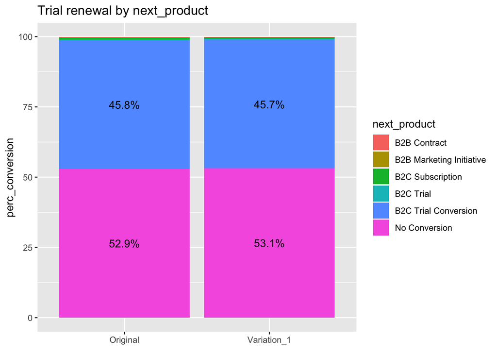

```r
#renewal rates

renewal_joined_df <- pageview %>%
  filter(time_stamp_utc <= end_date,
         time_stamp_utc >= start_date) %>%
  inner_join(optimizely %>%
               partitiontime_between(start_date, end_date) %>%
               filter(optimizely_campaign_name == 'MVT-400: Trial Roll on Test')
               , by = "event_root_id",suffix = c("_pvs", "_opt")) %>%
  left_join(conversions %>% filter(is_b2c == TRUE), by = "visitor_id", suffix = c("_pvs", "_cv")) %>%
  filter( is.na(order_dtm) | order_dtm >= time_stamp_utc) %>%
  mutate(visitor_id = as.character(visitor_id),
         visit_id = as.character(visit_id),
         conversion_visit_id = as.character(conversion_visit_id)) %>%
  distinct(optimizely_variations_name, user_guid_cv, order_dtm, arrangementtype_name, product_type, arrangementproduct_name, arrangement_id) %>%
  left_join(kuds %>% mutate(user_guid_cv = user_guid) %>% filter(user_status_date >= start_date, product_start_date >= start_date), by = "user_guid_cv") %>%
  collect()

renewal_joined_filtered_df <- renewal_joined_df %>%
  group_by(user_guid) %>%
    mutate(count = n_distinct(optimizely_variations_name)) %>% ungroup() %>% arrange(desc(count)) %>% filter(count == 1) %>%
  distinct(optimizely_variations_name, user_guid, order_dtm, user_status_date, product_type_y,
           product_name_rollup, product_arrangement_type, product_status, product_start_date,b2c_product_term_rollup, b2c_product_name_and_term,b2c_days_until_renewal, b2c_payment_failures, behav_has_cancelled) %>% filter(product_type_y != '') %>%
  arrange(user_guid, user_status_date)


renewal_list <- renewal_joined_filtered_df %>%distinct(optimizely_variations_name, user_guid, product_start_date, product_arrangement_type) %>% arrange(user_guid, product_start_date) %>%
  group_by(user_guid) %>% # it's the group by that works for partitioning
  mutate(next_product = lead(product_arrangement_type, order_by = product_start_date ,n = 1, default = NA)) %>%
  filter(product_arrangement_type %in% ("B2C Trial")) %>%
  mutate(count = n()) %>% # there are some users who took a trial twice
  slice(which.min(product_start_date)) %>% arrange(desc(count))

renewal_list$next_product <- ifelse(is.na(renewal_list$next_product), "No Conversion", renewal_list$next_product)

renewal_list_final <- renewal_list %>%
  group_by(optimizely_variations_name, product_arrangement_type, next_product) %>%
  summarise(trial_next_users = n_distinct(user_guid)) %>%
  ungroup() %>%
  group_by(optimizely_variations_name) %>%
  mutate(tot_users = sum(trial_next_users)) %>% ungroup() %>%
  mutate(perc_conversion = round((trial_next_users/tot_users)*100, 1)) %>% arrange(optimizely_variations_name, desc(trial_next_users))

renewal_list_final$next_product <- ifelse(is.na(renewal_list_final$next_product), "No Conversion", renewal_list_final$next_product)

# for visualising only top labels
top_labels <- renewal_list_final %>%
  group_by(optimizely_variations_name) %>%
  top_n(2, perc_conversion) %>%
  ungroup()

ggplot(renewal_list_final, aes(optimizely_variations_name, perc_conversion, fill = next_product)) +
  geom_col(position= "stack") +
  labs(title = "Trial renewal by next_product",
       x = element_blank()) +
  geom_text(data = top_labels, aes(label = paste0(perc_conversion, "%")),
            position = position_stack(vjust = 0.5))
```

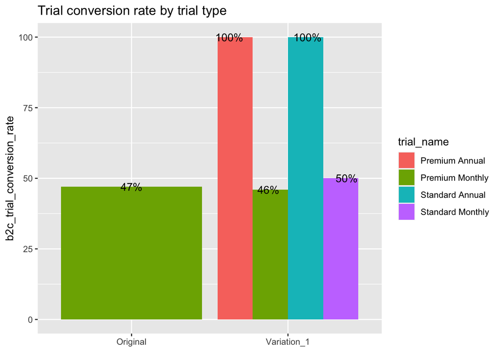

```r
trial_renewal_volumes <- renewal_list %>%
  inner_join(trial_product_list %>% mutate(user_guid = user_guid_cv), by =  "user_guid", suffix = c("_renewal", "_product")) %>%
  group_by(optimizely_variations_name_renewal, product_arrangement_type, next_product, trial_name) %>%
  summarise( users = n_distinct(user_guid)) %>%
  ungroup() %>%
  arrange(optimizely_variations_name_renewal, desc(users)) %>%
  #filter(#optimizely_variations_name_renewal == "Variation_1",
   #      trial_name %in% c("Premium Annual", "Standard Annual")) %>%
  group_by(optimizely_variations_name_renewal, trial_name) %>%
  mutate(trials = sum(users)) %>%
  ungroup() %>%
  filter(next_product %in% c("No Conversion", "B2C Trial Conversion")) %>%
  mutate(perc_renewal = round(users/trials*100,0)) %>%
  filter(next_product == "B2C Trial Conversion")

#merge renewal list with trial product to check on renewal

renewal_list_trials <- renewal_list %>%
  inner_join(trial_product_list %>% mutate(user_guid = user_guid_cv), by =  "user_guid", suffix = c("_renewal", "_product")) %>%
  group_by(optimizely_variations_name_renewal, product_arrangement_type, next_product, trial_name) %>%
  summarise( users = n_distinct(user_guid)) %>%
  ungroup() %>%
  arrange(optimizely_variations_name_renewal, desc(users)) %>%
  #filter(#optimizely_variations_name_renewal == "Variation_1",
   #      trial_name %in% c("Premium Annual", "Standard Annual")) %>%
  group_by(optimizely_variations_name_renewal, trial_name) %>%
  mutate(trials = sum(users)) %>%
  ungroup() %>%
  filter(next_product %in% c("No Conversion", "B2C Trial Conversion")) %>%
  mutate(perc_renewal = round(users/trials*100,0)) %>%
  pivot_wider(names_from = next_product, values_from = perc_renewal) %>%
  select(-trials, -product_arrangement_type, -users) %>%
  group_by(optimizely_variations_name_renewal, trial_name) %>%
  summarize_all(sum, na.rm = T) %>%
  ungroup()

#renaming column to avoid spaces
  colnames(renewal_list_trials)[colnames(renewal_list_trials) == "B2C Trial Conversion"] <- "b2c_trial_conversion_rate"


  ggplot(renewal_list_trials, aes(optimizely_variations_name_renewal,b2c_trial_conversion_rate, fill = trial_name)) +
  geom_col(position = "dodge") +
  labs(title = "Trial conversion rate by trial type",
       x = element_blank()) +
  geom_text(aes(label = paste0(b2c_trial_conversion_rate, "%")), position=position_dodge(width=1))
```